# Regression Week 4: Ridge regression

Next we're going to write a polynomial function that takes an SArray and a maximal degree and returns an SFrame with columns containing the SArray to all the powers up to the maximal degree.

```python
import csv
import math
import numpy as np
import pandas as pd
import patsy
import statsmodels.formula.api as sm
import sklearn
from sklearn import linear_model
```

# Polynomial_sframe function

Using the hints above complete the following function to create an SFrame consisting of the powers of an SArray up to a specific degree:

```python
def polynomial_dataframe(feature, degree): # feature is pandas.Series type
    # assume that degree >= 1
    # initialize the dataframe:
    poly_dataframe = pd.DataFrame()
    # and set poly_dataframe['power_1'] equal to the passed feature
    poly_dataframe['power_1'] = feature
    # first check if degree > 1
    if degree > 1:
        # then loop over the remaining degrees:
        for power in range(2, degree+1):
            # first we'll give the column a name:
            name = 'power_' + str(power)
            # assign poly_dataframe[name] to be feature^power; use apply(*)
            poly_dataframe[name] = feature.apply(lambda x: x**power)
    return poly_dataframe
```

```python
def getFormulaString(polynomialOrder):
    formula_string = "price ~ "
    for i in range(1,polynomialOrder):
        formula_string += "power_" + str(i) + " + "
    formula_string += "power_" + str(polynomialOrder)
    return(formula_string)
```

# Visualizing polynomial regression

Let's use matplotlib to visualize what a polynomial regression looks like on some real data.

```python
dtype_dict = {'bathrooms':float, 'waterfront':int, 'sqft_above':int, 'sqft_living15':float, 'grade':int, 'yr_renovated':int, 'price':float, 'bedrooms':float, 'zipcode':str, 'long':float, 'sqft_lot15':float, 'sqft_living':float, 'floors':str, 'condition':int, 'lat':float, 'date':str, 'sqft_basement':int, 'yr_built':int, 'id':str, 'sqft_lot':int, 'view':int}

sales = pd.read_csv('kc_house_data.csv', dtype=dtype_dict)
sales = sales.sort_values(['sqft_living', 'price'])
```

Let us revisit the 15th-order polynomial model using the 'sqft_living' input. Generate polynomial features up to degree 15 using `polynomial_sframe()` and fit a model with these features. When fitting the model, use an L2 penalty of 1.5e-5:

```python
poly15_data = polynomial_dataframe(sales['sqft_living'], 15)
l2_small_penalty = 1.5e-5
ridgeRegressionModel = linear_model.Ridge(alpha=l2_small_penalty, normalize=True)
ridgeRegressionModel.fit(poly15_data, sales['price'])
print ridgeRegressionModel.coef_
```

```
[  1.24873306e+02  -4.77376011e-02   3.01446238e-05  -2.44419942e-09
  -1.94153675e-13   8.54085686e-18   1.51142121e-21   8.27979094e-26
   6.52603100e-31  -3.27895017e-34  -3.87962315e-38  -2.72437650e-42
  -1.07790800e-46   3.78242694e-51   1.39790296e-54]
```

```python
import matplotlib.pyplot as plt
%matplotlib inline
```

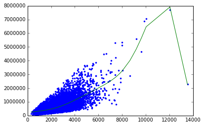

```python
plt.plot(poly15_data['power_1'],sales['price'],'.',
        poly15_data['power_1'], ridgeRegressionModel.predict(poly15_data),'-')
```

Recall from Module 3 (Polynomial Regression) that the polynomial fit of degree 15 changed wildly whenever the data changed. In particular, when we split the sales data into four subsets and fit the model of degree 15, the result came out to be very different for each subset. The model had a high variance. We will see in a moment that ridge regression reduces such variance. But first, we must reproduce the experiment we did in Module 3.

For this section, please download the provided csv files for each subset and load them with the given list of types.

```python
sales1 = pd.read_csv('wk3_kc_house_set_1_data.csv', dtype=dtype_dict)
sales1 = sales1.sort_values(['sqft_living', 'price'])
sales2 = pd.read_csv('wk3_kc_house_set_2_data.csv', dtype=dtype_dict)
sales2 = sales2.sort_values(['sqft_living', 'price'])
sales3 = pd.read_csv('wk3_kc_house_set_3_data.csv', dtype=dtype_dict)
sales3 = sales3.sort_values(['sqft_living', 'price'])
sales4 = pd.read_csv('wk3_kc_house_set_4_data.csv', dtype=dtype_dict)
sales4 = sales4.sort_values(['sqft_living', 'price'])
```

Just as we did in Module 3 (Polynomial Regression), fit a 15th degree polynomial on each of the 4 sets, plot the results and view the weights for the four models. This time, set

l2_small_penalty=1e-9 and use this value for the L2 penalty. Make sure to add "alpha=l2_small_penalty" and "normalize=True" to the parameter list of linear_model.Ridge.

```
[  5.44669387e+02  -3.55447594e-01   1.22446376e-04  -1.17175307e-08
  -3.90512396e-13  -1.39076538e-17   1.47860294e-20   6.87492334e-25
  -7.57204193e-29  -1.04097337e-32  -3.71843945e-37   3.39989324e-41
   5.56592021e-45   2.53761407e-49  -3.35152933e-53]
[  8.59362620e+02  -8.18118197e-01   4.28879892e-04  -9.12770134e-08
  -2.69606021e-12   3.73980536e-15  -1.42711930e-19  -6.30794911e-23
  -1.44559646e-27   7.44321685e-31   9.25865890e-35   3.27979365e-41
  -1.29543499e-42  -1.38781253e-46   1.66546446e-50]
[ -7.55395869e+02   9.75579420e-01  -4.58945929e-04   7.77957852e-08
   7.15013828e-12  -2.88602007e-15  -2.13678502e-20   3.38085306e-23
   2.19178151e-27  -1.97067790e-31  -4.15993065e-35  -1.80196334e-39
   3.19071213e-43   5.08456973e-47  -3.93304296e-51]
[  1.11944571e+03  -9.83760217e-01   3.38770904e-04   3.60377164e-08
  -4.37814002e-11   5.77191655e-15   7.66795297e-19  -9.49297834e-23
  -1.96030792e-26  -2.10884300e-32   3.31005137e-34   3.47733771e-38
  -2.43039212e-42  -8.79553261e-46   6.44569661e-50]
```

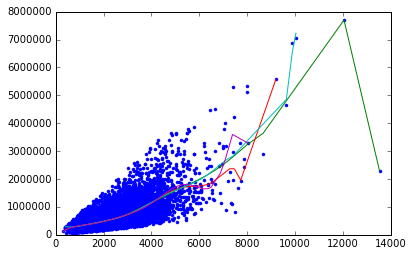

```python
l2_small_penalty=1e-9

poly15_data1 = polynomial_dataframe(sales1['sqft_living'], 15)
ridgeRegressionModel1 = linear_model.Ridge(alpha=l2_small_penalty, normalize=True)
ridgeRegressionModel1.fit(poly15_data1, sales1['price'])
print ridgeRegressionModel1.coef_

poly15_data2 = polynomial_dataframe(sales2['sqft_living'], 15)
ridgeRegressionModel2 = linear_model.Ridge(alpha=l2_small_penalty, normalize=True)
ridgeRegressionModel2.fit(poly15_data2, sales2['price'])
print ridgeRegressionModel2.coef_

poly15_data3 = polynomial_dataframe(sales3['sqft_living'], 15)
ridgeRegressionModel3 = linear_model.Ridge(alpha=l2_small_penalty, normalize=True)
ridgeRegressionModel3.fit(poly15_data3, sales3['price'])
print ridgeRegressionModel3.coef_

poly15_data4 = polynomial_dataframe(sales4['sqft_living'], 15)
ridgeRegressionModel4 = linear_model.Ridge(alpha=l2_small_penalty, normalize=True)
ridgeRegressionModel4.fit(poly15_data4, sales4['price'])
print ridgeRegressionModel4.coef_

plt.plot(poly15_data['power_1'],sales['price'],'.',
        poly15_data1['power_1'], ridgeRegressionModel1.predict(poly15_data1),'-',
        poly15_data2['power_1'], ridgeRegressionModel2.predict(poly15_data2),'-',
        poly15_data3['power_1'], ridgeRegressionModel3.predict(poly15_data3),'-',
        poly15_data4['power_1'], ridgeRegressionModel4.predict(poly15_data4),'-')
```

## Ridge regression comes to rescue

Generally, whenever we see weights change so much in response to change in data, we believe the variance of our estimate to be large. Ridge regression aims to address this issue by penalizing "large" weights. (The weights looked quite small, but they are not that small because 'sqft_living' input is in the order of thousands.)

Fit a 15th-order polynomial model on set_1, set_2, set_3, and set_4, this time with a large L2 penalty. Make sure to add "alpha=l2_large_penalty" and "normalize=True" to the parameter list, where the value of l2_large_penalty is given by

l2_large_penalty=1.23e2 These curves should vary a lot less, now that you introduced regularization.

```
[  2.32806803e+00   3.53621608e-04   3.31969692e-08   2.00082477e-12
   1.11492559e-16   6.57786122e-21   4.12939525e-25   2.70393755e-29
   1.81614763e-33   1.23824277e-37   8.51872481e-42   5.89455598e-46
   4.09542560e-50   2.85464889e-54   1.99547476e-58]
[  2.09756903e+00   3.90817483e-04   6.67189944e-08   8.90002997e-12
   9.72639877e-16   9.69733682e-20   9.50564475e-24   9.44491031e-28
   9.57191338e-32   9.86945155e-36   1.03101115e-39   1.08729784e-43
   1.15453748e-47   1.23211305e-51   1.31986696e-55]
[  2.28906258e+00   4.12472190e-04   6.08835345e-08   6.58572163e-12
   6.15278155e-16   5.64446634e-20   5.28834396e-24   5.07091402e-28
   4.94657273e-32   4.88043809e-36   4.85009106e-40   4.84161534e-44
   4.84635021e-48   4.85883628e-52   4.87558469e-56]
[  2.08596194e+00   4.05035772e-04   7.46864647e-08   1.13096608e-11
   1.45864442e-15   1.73561251e-19   2.01609632e-23   2.34605255e-27
   2.75636073e-31   3.27043069e-35   3.91046855e-39   4.70118041e-43
   5.67212304e-47   6.85958087e-51   8.30843630e-55]
```

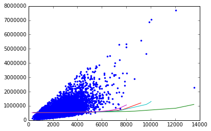

```python
l2_large_penalty=1.23e+2

poly15_data1 = polynomial_dataframe(sales1['sqft_living'], 15)
ridgeRegressionModel1 = linear_model.Ridge(alpha=l2_large_penalty, normalize=True)
ridgeRegressionModel1.fit(poly15_data1, sales1['price'])
print ridgeRegressionModel1.coef_

poly15_data2 = polynomial_dataframe(sales2['sqft_living'], 15)
ridgeRegressionModel2 = linear_model.Ridge(alpha=l2_large_penalty, normalize=True)
ridgeRegressionModel2.fit(poly15_data2, sales2['price'])
print ridgeRegressionModel2.coef_

poly15_data3 = polynomial_dataframe(sales3['sqft_living'], 15)
ridgeRegressionModel3 = linear_model.Ridge(alpha=l2_large_penalty, normalize=True)
ridgeRegressionModel3.fit(poly15_data3, sales3['price'])
print ridgeRegressionModel3.coef_

poly15_data4 = polynomial_dataframe(sales4['sqft_living'], 15)
ridgeRegressionModel4 = linear_model.Ridge(alpha=l2_large_penalty, normalize=True)
ridgeRegressionModel4.fit(poly15_data4, sales4['price'])
print ridgeRegressionModel4.coef_

plt.plot(poly15_data['power_1'],sales['price'],'.',
        poly15_data1['power_1'], ridgeRegressionModel1.predict(poly15_data1),'-',
        poly15_data2['power_1'], ridgeRegressionModel2.predict(poly15_data2),'-',
        poly15_data3['power_1'], ridgeRegressionModel3.predict(poly15_data3),'-',
        poly15_data4['power_1'], ridgeRegressionModel4.predict(poly15_data4),'-')
```

```python
train_valid_shuffled = pd.read_csv('wk3_kc_house_train_valid_shuffled.csv', dtype=dtype_dict)
test = pd.read_csv('wk3_kc_house_test_data.csv', dtype=dtype_dict)
```

Divide the combined training and validation set into equal segments. Each segment should receive n/k elements, where n is the number of observations in the training set and k is the number of segments. Since the segment 0 starts at index 0 and contains n/k elements, it ends at index (n/k)-1. The segment 1 starts where the segment 0 left off, at index (n/k). With n/k elements, the segment 1 ends at index (n*2/k)-1. Continuing in this fashion, we deduce that the segment i starts at index (n*i/k) and ends at (n*(i+1)/k)-1.

With this pattern in mind, we write a short loop that prints the starting and ending indices of each segment, just to make sure you are getting the splits right.

```python
n = len(train_valid_shuffled)
k = 10 # 10-fold cross-validation

for i in xrange(k):
    start = (n*i)/k
    end = (n*(i+1))/k-1
    print i, (start, end)
```

```
0 (0, 1938)
1 (1939, 3878)
2 (3879, 5817)
3 (5818, 7757)
4 (7758, 9697)
5 (9698, 11636)
6 (11637, 13576)
7 (13577, 15515)
8 (15516, 17455)
9 (17456, 19395)
```

Now we are ready to implement k-fold cross-validation. Write a function that computes k validation errors by designating each of the k segments as the validation set. It accepts as parameters (i) k, (ii) l2_penalty, (iii) dataframe containing input features (e.g. poly15_data) and (iv) column of output values (e.g. price). The function returns the average validation error using k segments as validation sets. We shall assume that the input dataframe does not contain the output column.

For each i in [0, 1, ... k-1]:

Compute starting and ending indices of segment i and call 'start' and 'end'

Form validation set by taking a slice (start:end+1) from the data.

Form training set by appending slice (end+1:n) to the end of slice (0:start).

Train a linear model using training set just formed, with a given l2_penalty

Compute validation error (RSS) using validation set just formed

```python
def k_fold_cross_validation(k, l2_penalty, data, output):
    n = len(data)
    average_error = 0
    for i in range(0,k):
        start = (n*i)/k
        end = (n*(i+1))/k
        validation_data = data[start:end+1]
        training_data = data[0:start].append(data[end+1:n])
        validation_output = output[start:end+1]
        training_output = output[0:start].append(output[end+1:n])
        ridgeRegressionModel = linear_model.Ridge(alpha=l2_penalty, normalize=True)
        ridgeRegressionModel.fit(training_data, training_output)
        yPredicted = ridgeRegressionModel.predict(validation_data)
        print k, np.linalg.norm(np.subtract(yPredicted,validation_output))*np.linalg.norm(np.subtract(yPredicted,validation_output))
        average_error += np.linalg.norm(np.subtract(yPredicted,validation_output))*np.linalg.norm(np.subtract(yPredicted,validation_output))
    average_error = average_error / k
    return average_error
```

```python
poly15_data_train = polynomial_dataframe(train_valid_shuffled['sqft_living'], 15)
poly15_data_test = polynomial_dataframe(test['sqft_living'],15)

k = 10

for l2_penalty in np.logspace(3,9,num=13):
    l2_penalty_error = k_fold_cross_validation(k,l2_penalty,poly15_data_train, train_valid_shuffled['price'])
    print l2_penalty,l2_penalty_error
```

```
10 2.47439039057e+14
10 2.53376475428e+14
10 2.13918107646e+14
10 2.58046563779e+14
10 2.44815697303e+14
10 2.90554182798e+14
10 3.16475383348e+14
10 2.86840441925e+14
10 2.26782818566e+14
10 3.11930035766e+14
1000.0 2.65017874562e+14
10 2.48000160015e+14
10 2.53921730866e+14
10 2.14457470313e+14
10 2.58552848215e+14
```

[output cut: 128 more lines]

```python
ridgeRegressionModel = linear_model.Ridge(alpha=1000.0, normalize=True)
ridgeRegressionModel.fit(poly15_data_train, train_valid_shuffled['price'])
yPredicted = ridgeRegressionModel.predict(poly15_data_test)
print np.linalg.norm(np.subtract(yPredicted,test['price']))*np.linalg.norm(np.subtract(yPredicted,test['price']))
```

```
2.83856861224e+14
```